# My R Code Notes

tags= #r_code #ggplot2 #data_science

```r
library(tidyverse)
```

# Getting and Writing Data

## Importing Data

### Tab Delimited Text

```r
mydata <- read.delim("my_data.txt", header=TRUE, na.strings="NA")
```

### Importing Multiple CSV files at once

[Stack Overflow - Importing Multiple CSV files in R](http://stackoverflow.com/questions/11433432/importing-multiple-csv-files-into-r)

```r
temp = list.files(pattern="*.csv")
for (i in 1:length(temp)) assign(temp[i], read.csv(temp[i]))
```

## Writing Out

### Write out a tab delimited text

```r
#tab delimitted text file
write.table(my_data, "my_data_output", sep="\t")
```

# Wrangling

## Data Frames

### Remove Columns

[Remove an entire column from a data.frame in R](https://stackoverflow.com/questions/6286313/remove-an-entire-column-from-a-data-frame-in-r)

Remove a column

```r
> Data$genome <- NULL
> head(Data)
   chr region
1 chr1    CDS
2 chr1   exon
3 chr1    CDS
4 chr1   exon
5 chr1    CDS
6 chr1   exon
```

Remove multiple columns

```r
Data[1:2] <- list(NULL)  # Marek
Data[1:2] <- NULL        # does not work!
```

### Add columns to data frame

[Adding a New Column to a Data Frame](https://lembra.wordpress.com/2010/03/12/adding-new-column-to-a-data-frame-in-r/)

```r
df["MY_NEW_COLUMN"] <- NA # That creates the new column named "MY_NEW_COLUMN" filled with "NA"
df[c("E","F","G","H","I")] <- NA #create multiple empty columns
```

See also [Adding and Removing Columns - R Cookbook](http://www.cookbook-r.com/Manipulating_data/Adding_and_removing_columns_from_a_data_frame/)

### Add Group Information to Subjects

When you want to put an observation into a group (e.g Case vs. Control), you need to create a new variable. A simple way to do this is to create a vector(s) that contains the Group members and then use `mutate` with `if_else()`.

In this example, I created a group called “Domestic” for some cars based on their manufacturer variable.

```r
domestic = c("chevrolet", "dodge", "ford", "jeep", "lincoln", "mercury", "pontiac")
mutate(mpg, Location = if_else(manufacturer %in% domestic, "Domestic", "Foreign"))
```

| manufacturer | model | displ | year | cyl | trans | drv | cty | hwy | fl | class | Location |
| --- | --- | --- | --- | --- | --- | --- | --- | --- | --- | --- | --- |
| audi | a4 | 1.8 | 1999 | 4 | auto(l5) | f | 18 | 29 | p | compact | Foreign |
| audi | a4 | 1.8 | 1999 | 4 | manual(m5) | f | 21 | 29 | p | compact | Foreign |
| audi | a4 | 2.0 | 2008 | 4 | manual(m6) | f | 20 | 31 | p | compact | Foreign |
| audi | a4 | 2.0 | 2008 | 4 | auto(av) | f | 21 | 30 | p | compact | Foreign |
| audi | a4 | 2.8 | 1999 | 6 | auto(l5) | f | 16 | 26 | p | compact | Foreign |
| audi | a4 | 2.8 | 1999 | 6 | manual(m5) | f | 18 | 26 | p | compact | Foreign |
| audi | a4 | 3.1 | 2008 | 6 | auto(av) | f | 18 | 27 | p | compact | Foreign |
| audi | a4 quattro | 1.8 | 1999 | 4 | manual(m5) | 4 | 18 | 26 | p | compact | Foreign |
| audi | a4 quattro | 1.8 | 1999 | 4 | auto(l5) | 4 | 16 | 25 | p | compact | Foreign |
| audi | a4 quattro | 2.0 | 2008 | 4 | manual(m6) | 4 | 20 | 28 | p | compact | Foreign |

[output cut: 224 more lines]

### Merge Data Frames by Variable

```r
data <- merge(d1, d2, by="Patient.ID")
```

### Create multiple columns with different names and data

[Adding multiple columns simultaneously with different values in R -SO](https://stackoverflow.com/questions/48351750/adding-multiple-columns-simultaneously-with-different-values-in-r/48351810#48351810)

```r
library('tidyverse')

df <- head(cars)

mutate(df, Subject = 'F1', Slide = '1A')
```

| speed | dist | Subject | Slide |
| --- | --- | --- | --- |
| 4 | 2 | F1 | 1A |
| 4 | 10 | F1 | 1A |
| 7 | 4 | F1 | 1A |
| 7 | 22 | F1 | 1A |
| 8 | 16 | F1 | 1A |
| 9 | 10 | F1 | 1A |

### Merge multiple data frames using `merge_all()

```r
reshape::merge_all(your_list_with_dfs, ...)
```

## Factors and Categories

### Change Order of Factor Levels

```r
pc$Group <- factor(pc$Group, levels = c('Control','Case'),ordered = TRUE)
```

### Categorizing Continuous Data

Purpose: When you want take numerical values and bin them into categories.

Use cases:

- I have expression values of ISH puncta inside cells. I want to categorize expression levels into discrete categories (high, medium, low).

[Categorize continuous data](https://stackoverflow.com/questions/40380112/categorize-continuous-variable-with-dplyr)

With [`cut`](https://www.rdocumentation.org/packages/base/versions/3.4.3/topics/cut)

```r
df$category <- cut(df$a, breaks=c(-Inf, 0.5, 0.6, Inf), labels=c("low","middle","high"))
```

With [`dplyr`](http://dplyr.tidyverse.org/reference/mutate.html)

```r
res <- df %>% mutate(category=cut(a, breaks=c(-Inf, 0.5, 0.6, Inf), labels=c("low","middle","high")))
```

## Subsetting

### `select()` from `dplyr()`

> “The select() function can be used to select columns of a data frame that you want to focus on. Often you’ll have a large data frame containing “all” of the data, but any given analysis might only use a subset of variables or observations. The select() function allows you to get the few columns you might need.” - Excerpt From: Roger D. Peng. “R Programming for Data Science.” iBooks.
- [`select()` - R4DS](http://r4ds.had.co.nz/transform.html#select-columns-with-select)
- [`select()` - Tidyverse](http://dplyr.tidyverse.org/reference/select.html)

```r
> names(chicago)[1:3]
[1] "city" "tmpd" "dptp"
> subset <- select(chicago, city:dptp)
> head(subset)
  city tmpd   dptp
1 chic 31.5 31.500
2 chic 33.0 29.875
3 chic 33.0 27.375
4 chic 29.0 28.625
5 chic 32.0 28.875
6 chic 40.0 35.125
```

# Describing Data

## Summary Statistics

### `summarize()` from `dplyr`

```r
mpg_summary <- mpg %>%
  group_by(class) %>% # group by grouping variable class
  summarize(hwy_sd = sd(hwy), hwy_mean = mean(hwy)) %>% # find the sd and se of the mean
  mutate(hwy_se = hwy_sd/sqrt(length(mpg$hwy))) # add the standard error of the mean

mpg_summary
```

| class | hwy_sd | hwy_mean | hwy_se |
| --- | --- | --- | --- |
| 2seater | 1.303840 | 24.80000 | 0.08523472 |
| compact | 3.781620 | 28.29787 | 0.24721221 |
| midsize | 2.135930 | 27.29268 | 0.13963008 |
| minivan | 2.062655 | 22.36364 | 0.13483997 |
| pickup | 2.274280 | 16.87879 | 0.14867432 |
| subcompact | 5.375012 | 28.14286 | 0.35137554 |
| suv | 2.977973 | 18.12903 | 0.19467619 |

### `summaryBy` (Base R)

```r
summaryBy(Age ~ med_year, data = data, FUN = function(x) { c(m = mean(x, na.rm=TRUE), s = sd(x, na.rm=TRUE), n =length(x), r=range(x,na.rm=TRUE)) }
```

### Summarize with `psych( )` package

```r
library(psych)
describeBy(my_data, my_data$Group, mat=T)
```

# Visualize

## ggplot2

ggplot2 is a package that is used to make attractive and flexible plots. It’s based on the idea of graphics composed of various layers.

> Our new template takes seven parameters, the bracketed words that appear in the template. In practice, you rarely need to supply all seven parameters to make a graph because ggplot2 will provide useful defaults for everything except the data, the mappings, and the geom function.

> The seven parameters in the template compose the grammar of graphics, a formal system for building plots. The grammar of graphics is based on the insight that you can uniquely describe any plot as a combination of a dataset, a geom, a set of mappings, a stat, a position adjustment, a coordinate system, and a faceting scheme. (http://r4ds.had.co.nz/data-visualisation.html#first-steps)

```
ggplot(data = <DATA>) +
  <GEOM_FUNCTION>(
     mapping = aes(<MAPPINGS>),
     stat = <STAT>,
     position = <POSITION>
  ) +
  <COORDINATE_FUNCTION> +
  <FACET_FUNCTION>
```

And from [socviz](http://socviz.co/makeplot.html#build-your-plots-layer-by-layer)

> - Tell the ggplot() function what our data is.The data = … step.
> - Tell ggplot() what relationships we want to see.The mapping = aes(…) step. For convenience we will put the results of the first two steps in an object called p.
> - Tell ggplot how we want to see the relationships in our data.Choose a geom.
> - Layer on geoms as needed, by adding them to the p object one at a time.
> - Use The scale_, family, labs() and guides() functions. some additional functions to adjust scales, labels, tick marks, titles. We’ll learn more about some of these functions shortly.

## Histograms

### Basic Histogram (ggplot2)

- Take the data and add a `geom_histogram` layer with `aes()` set to the variable you’re interested in.

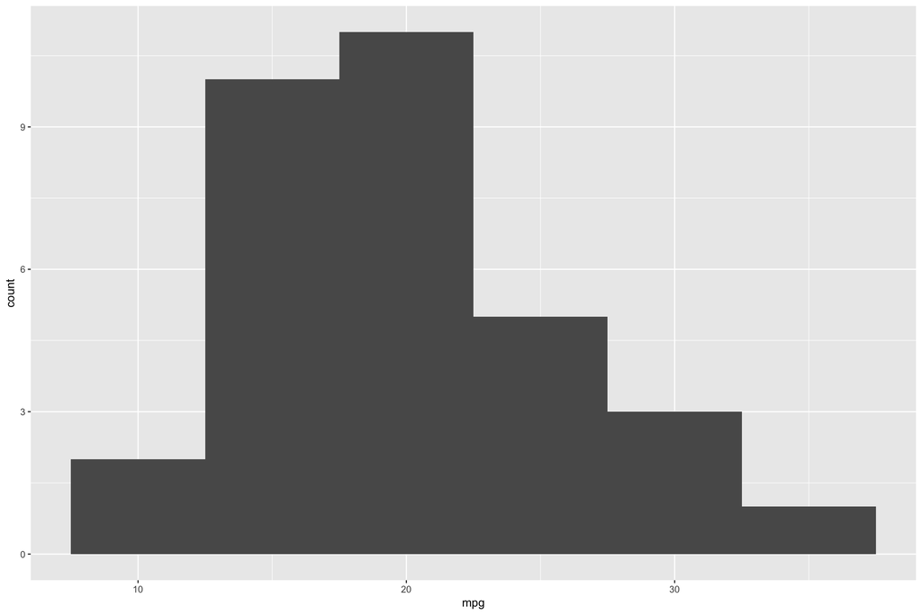

```r
ggplot(mtcars) + geom_histogram(aes(mpg), binwidth = 5)
```

### Two histograms overlaid (ggplot2)

- Take a dataset. Make a histogram, use `aes()` for the variable of interest. Add another `geom_hist()` layer doing the same. You can change `binwidth` and `alpha`

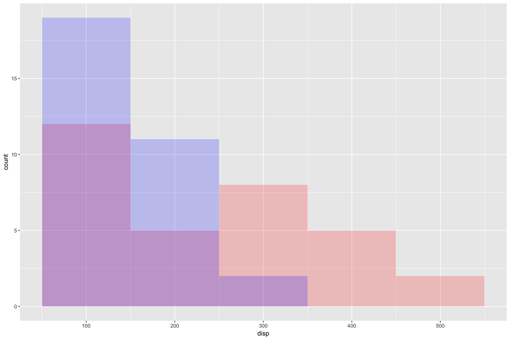

```r
ggplot(mtcars) + geom_histogram(aes(disp), fill="red", alpha=0.2, binwidth = 100)  + geom_histogram(aes(hp), fill="blue", alpha=0.2, binwidth = 100)
```

## Scatter Plots

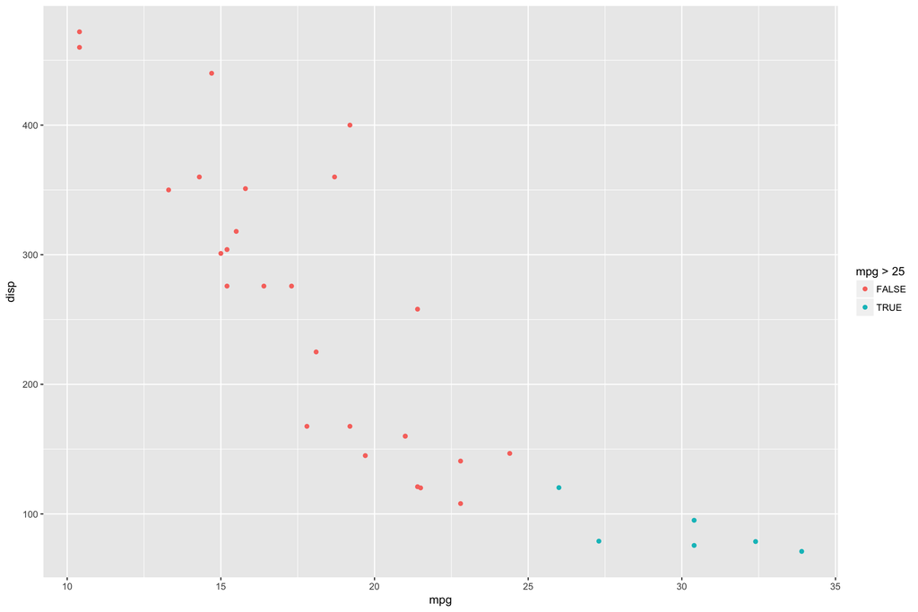

```r
#using ggplot2

ggplot(mtcars) + geom_point(aes(x = mpg, y = disp, color= mpg >25))
```

## Mosaic Plot

For Categorical x Categorical Data (Contingency Table)

[`ggmosiac` package](https://cran.r-project.org/web/packages/ggmosaic/vignettes/ggmosaic.html)

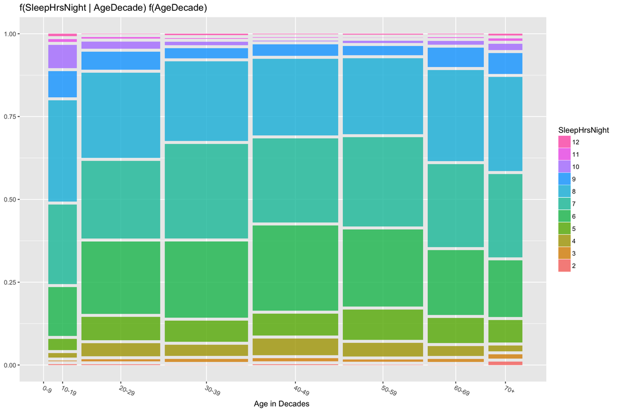

```r
library(ggmosaic)
library(NHANES)
 ggplot(data = NHANES) +
   geom_mosaic(aes(weight = Weight, x = product(SleepHrsNight, AgeDecade), fill=factor(SleepHrsNight)), na.rm=TRUE) +    theme(axis.text.x=element_text(angle=-25, hjust= .1)) + labs(x="Age in Decades ", title='f(SleepHrsNight | AgeDecade) f(AgeDecade)') + guides(fill=guide_legend(title = "SleepHrsNight", reverse = TRUE))
```

## Bar Plots

### Basic Bar Plot with Overlaid Points

- Each geom is a layer. To get the mean of the data_points, no conversion is necessary. You can use the `stat=summary` argument. Error bars, however, must be calculated and entered into the data.

Plotting means and error bars - R Cookbook

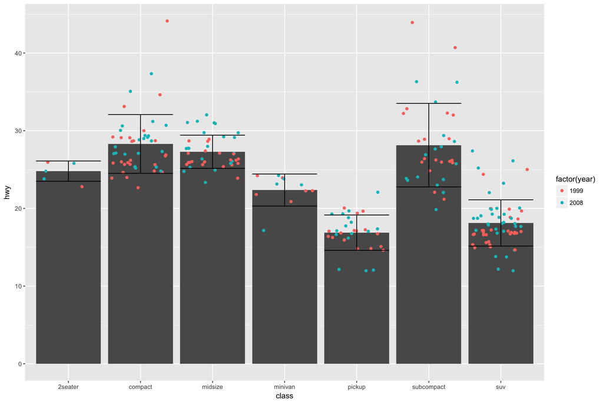

```r
#get summary statistics
mpg_summary <- mpg %>%
  group_by(class) %>% # group by grouping variable class
  summarize(hwy_sd = sd(hwy), hwy_mean = mean(hwy)) %>% # find the sd and se of the mean
  mutate(hwy_se = hwy_sd/sqrt(length(mpg$hwy))) # add the standard error of the mean

#build base bar plot
p = ggplot(mpg, aes(x=class, y=hwy)) + geom_bar(stat="summary", fun.y="mean") + geom_jitter(aes(color=factor(year)))

#add error bars
p + geom_errorbar(data=mpg_summary, aes(x=class, y=hwy_sd, ymin=hwy_mean-hwy_sd, ymax = hwy_mean+ hwy_sd))
```

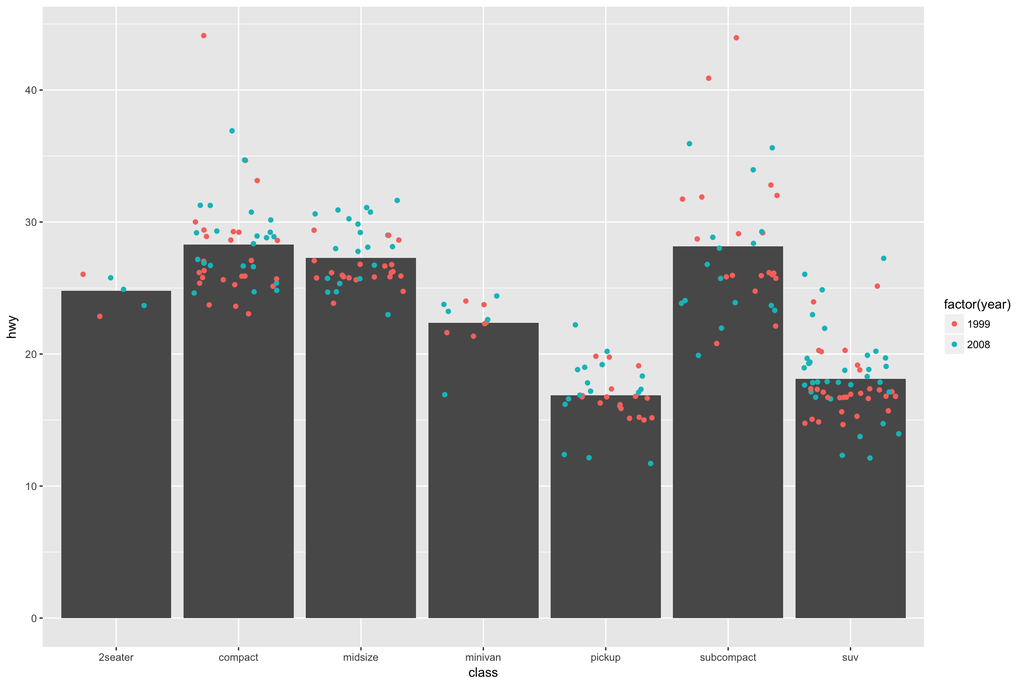

```r
p
```

## Arranging Plots

[Side by Side ggplot2 plots](https://stackoverflow.com/questions/1249548/side-by-side-plots-with-ggplot2)

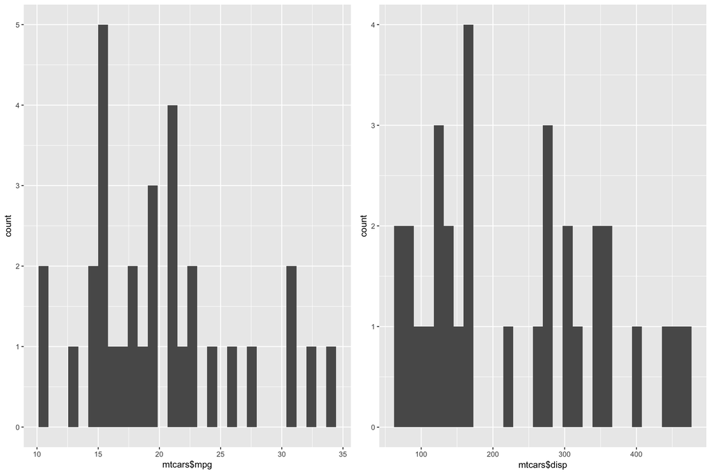

```r
require(gridExtra)
plot1 <- qplot(mtcars$mpg)
plot2 <- qplot(mtcars$disp)
grid.arrange(plot1, plot2, ncol=2)
```

# Genomic Analysis

## Volcano Plot

[Volcano Plots with DESeq2](https://twbattaglia.github.io/2016/12/17/volcano-plot/)

```r
simple <- ggplot(df, aes(x = lfc, y = pvalue)) +
  geom_point(size = 3, alpha = 0.7, na.rm = T) + # Make dots bigger
  theme_bw(base_size = 16) + # change theme
  ggtitle(label = "Volcano Plot", subtitle = "Simple black & white") + # Add a title
  xlab(expression(log[2]("Treatment" / "Untreated"))) + # x-axis label
  ylab(expression(-log[10]("adjusted p-value"))) + # y-axis label
  geom_vline(xintercept = c(-2,2), colour = "darkgrey") + # Add cutoffs
  geom_hline(yintercept = 1.3, colour = "darkgrey") + # Add cutoffs
  geom_vline(xintercept = 0, colour = "black") + # Add 0 lines
  scale_colour_gradient(low = "black", high = "black", guide = FALSE) + # Color black
  scale_x_continuous(limits = c(-4, 4)) # min/max of lfc

# Plot figure
simple
```

Color can be added like this.

```r
# Modify dataset to add new coloumn of colors

data <- data %>%
  mutate(color = ifelse(data$lfc > 0 & data$pvalue > 1.3,
                        yes = "Treated",
                        no = ifelse(data$lfc < 0 & data$pvalue > 1.3,
                                    yes = "Untreated",
                                    no = "none")))

# Color corresponds to fold change directionality
colored <- ggplot(data, aes(x = lfc, y = pvalue)) +
  geom_point(aes(color = factor(color)), size = 1.75, alpha = 0.8, na.rm = T) + # add gene points
  theme_bw(base_size = 16) + # clean up theme
  theme(legend.position = "none") + # remove legend
  ggtitle(label = "Volcano Plot", subtitle = "Colored by directionality") +  # add title
  xlab(expression(log[2]("Treated" / "Untreated"))) + # x-axis label
  ylab(expression(-log[10]("adjusted p-value"))) + # y-axis label
  geom_vline(xintercept = 0, colour = "black") + # add line at 0
  geom_hline(yintercept = 1.3, colour = "black") + # p(0.05) = 1.3
  annotate(geom = "text",
           label = "Untreated",
           x = -2, y = 85,
           size = 7, colour = "black") + # add Untreated text
  annotate(geom = "text",
           label = "Treated",
           x = 2, y = 85,
           size = 7, colour = "black") + # add Treated text
  scale_color_manual(values = c("Treated" = "#E64B35",
                                "Untreated" = "#3182bd",
                                "none" = "#636363")) # change colors

# Plot figure
colored
```

# Programming

## For Loops

### Assigning a new name to a variable each iteration with a for loop

Goal: With each iteration of the `For()` loop, create a new variable that appends the iterator variable to the new variable. This is useful for creating objects as you go through a list or sequence.

- [Change variable name in `For()` loop](https://stackoverflow.com/questions/16566799/change-variable-name-in-for-loop-using-r)
- [More on the `assign()` function](http://stat.ethz.ch/R-manual/R-patched/library/base/html/assign.html)

```r
for (i in seq(1,6)){
 name <- paste("data", "_", i, sep = "")
 assign(name, read_excel("Left_Female.xlsx", i))
}
```

# Miscellaneous

[Remove objects by search term](http://stackoverflow.com/questions/11624885/remove-multiple-objects-with-rm)

```
rm(list=ls(pattern="temp"))
```

[Make a list of data frames based on naming pattern](http://stackoverflow.com/questions/17499013/how-do-i-make-a-list-of-data-frames)

```
df_list = mget(ls(pattern = "df[0-9]"))
# this would match any object with "df" followed by a digit in its name
# you can test what objects will be got by just running the
ls(pattern = "df[0-9]")
# part and adjusting the pattern until it gets the right objects.
```

Note: The critical piece here is `mget()` which calls the value of a named object

[Filter a list by class of list item](http://stackoverflow.com/questions/36661704/filter-values-of-a-list-in-r)

```
Filter(function(x) is(x, "data.frame"), mget(ls(pattern="_list")))
```

## Sequence Generation

### Binary (0,1) Random Collection

[Make binary vector with 0,1](https://stackoverflow.com/questions/26137662/r-generate-number-vector-only-contains-0-and-1-with-certain-length)

```r
X <- 10
sample(c(0,1), replace=TRUE, size=X)
```

```
##  [1] 1 0 1 0 1 1 1 0 0 1
```

## Annotate `geom_point` or other plot selectively using `annotate()`

[ggplot XY scatter - how to change alpha transparency for select points?](https://stackoverflow.com/questions/32423167/ggplot-xy-scatter-how-to-change-alpha-transparency-for-select-points)

```r
## you start here
library(ggplot2)
special.points <- sample(1:n, 7)
## then add annotate text
ggplot(df, aes(x=SeqIdentityMean,
               y=SeqIdentityStdDev)) +
  geom_point(alpha=0.05) +
  annotate("point",
           df$SeqIdentityMean[special.points],
           df$SeqIdentityStdDev[special.points],
           col="red") +
  annotate("text",
           df$SeqIdentityMean[special.points],
           df$SeqIdentityStdDev[special.points],
           #text we want to display
           label=round(df$SeqIdentityStdDev[special.points],1),
           #adjust horizontal position of text
           hjust=-0.1)
```